# Monte Carlo Methods in Inference

CHEN YONG yongc2

October 27, 2018

## Exercise 1

**Antithetic method.** Suppose we want to estimate the mean of the Weibull distribution with the following pdf
$$f(x) = \frac{4}{5} \left(\frac{x}{5}\right)^3 e^{-(x/5)^4}, \quad
0<x<\infty.$$

1. Use the inverse CDF method to estimate the mean. (Sample size $n=1000$)

```r
n=1000
y=runif(n,0,1)
x=(-5^4*log(1-y))^0.25
mean(x)
```

```
## [1] 4.475
```

2. Use an antithetic method to estimate the mean. (Sample size $n=1000$)

```r
n=1000
u=runif(n,0,1)
f=function(x){(-5^4*log(1-x))^0.25}
sum((f(u)+f(1-u))/2)/n #the mean
```

```
## [1] 4.533
```

3. Compare the variance of these two estimates. Which one has smaller variance?

```r
M=replicate(1000,expr={
  y=runif(1000,0,1)
  mean((-5^4*log(1-y))^0.25)
})
var(M)
```

```
## [1] 0.001566
```

```r
I=replicate(1000,expr={
  u=runif(1000,0,1)
  f=function(x){(-5^4*log(1-x))^0.25}
  sum((f(u)+f(1-u))/2)/n
})
var(I)
```

```
## [1] 9.95e-07
```

The one with antithetic method has smaller variance.

## Exercise 2

**Bayesian Statistics** 1. Write down the posterior distribution of $\theta$, $g(\theta|X)$. $g(\theta|x)\varpropto \prod_{i=1}^{n}\theta e^{-\theta x}\cdot \theta^2 e^{-2\theta}$

2. Suppose $n=5$ and we observe that $x_1=0.5, x_2=1, x_3=0.1, x_4=1.7, x_5=1.4$. Please estimate the posterior mean of $\theta$ based on $1000$ simulated $\theta$ from its prior distribution.

```r
r=rgamma(1000,3,2) #generate gamma random samples
x=c(0.5,1,0.1,1.7,1.4)
gx=function(t){prod(t*exp(-t*x))*t^2*exp(-2*t)} #posterior distribution
pm=numeric(1000)
for (i in 1:1000){
  pm[i]=gx(r[i]) #plug in
}
mean(pm) #compute simple mean
```

```
## [1] 0.000591
```

3. Suppose $n=5$ and we observe that $x_1=0.5, x_2=1, x_3=0.1, x_4=1.7, x_5=1.4$.
1. 1.Randomly generate y~Gamma(3,2), U~U(0,1)  
   2.if U<= g(y|x)/0.0092/g(y),accept y as a sample  
   3.if not satisfied, start again from 1
   2. Implement your acceptance-rejection sampling algorithm with R code. Plot the histogram of your generated sample and compare your sample mean with your estimated posterior mean obatained in Ex.2.2.

```r
n=1000
x=c(0.5,1,0.1,1.7,1.4)
fg=function(t){prod(t*exp(-t*x))}
M=fg(5/4.7) #when theta=5/4,7, g(theta|x)/g(x) reachs its maximum
k=0
j=0
z=rep(0,times=n)
while(k<n){
  y=rgamma(1,3,2) #samples from instrumental distribution
  u=runif(1)
  j=j+1
  if(u<=fg(y)/M){
    k=k+1
    z[k]=y
  }
}
mean(z)
```

```
## [1] 1.192
```

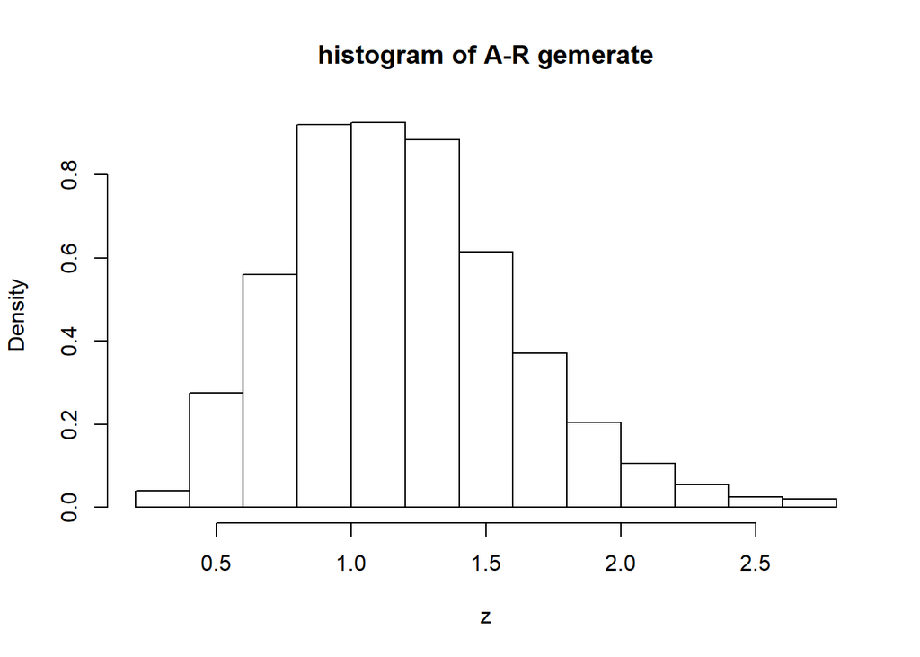

```r
hist(z,probability = T,main="histogram of A-R gemerate")
```

## Exercise 3

**Exercise 6.6**

```r
sk <- function(x) {
  #computes the sample skewness coeff.
  xbar=mean(x)
  m3=mean((x - xbar)^3)
  m2=mean((x - xbar)^2)
  return( m3 / m2^1.5 )
}
n=1000
b=numeric(n)
for (i in 1:n){
  x=rnorm(1000,0,1)
  b[i]=sk(x)

}
q=c(0.025,0.05,0.95,0.975)
q_hat=quantile(b,probs=q) #step 3
q_hat
```

```
##    2.5%      5%     95%   97.5%
## -0.1478 -0.1253  0.1319  0.1488
```

```r
sqrt(q*(1-q)/n/dnorm(q_hat)) #step4: standard error
```

```
##     2.5%       5%      95%    97.5%
## 0.007859 0.010955 0.010959 0.007860
```

```r
qnorm(q,0,sqrt(6/n)) #step5: compare with the theoretical values
```

```
## [1] -0.1518 -0.1274  0.1274  0.1518
```

## Exercise 4

```r
mse=matrix(0,9,2)
trimmed.mse=function(n,k,p){
  #n:sample sizes;k:level;p:monte carlo sample sizes
  tmean=numeric(p)
  for (i in 1:p) {
    x=rcauchy(n,0,1) #generate samples from standard cauchy
    x=sort(x) #sort samples increasingly
    tmean[i]=sum(x[(k+1):(n-k)])/(n-2*k)
  }
  mse=mean(tmean^2)
  return(c(k,mse))
}

for (k in 1:9) {
  mse[k,]=trimmed.mse(20,k,1000)
}
mse=data.frame(mse)
names(mse)=c('k','MSE')
mse
```

```
##   k    MSE
## 1 1 0.8792
## 2 2 0.4365
## 3 3 0.2726
## 4 4 0.1994
## 5 5 0.1539
## 6 6 0.1457
## 7 7 0.1366
## 8 8 0.1284
## 9 9 0.1344
```

## Exercise 5

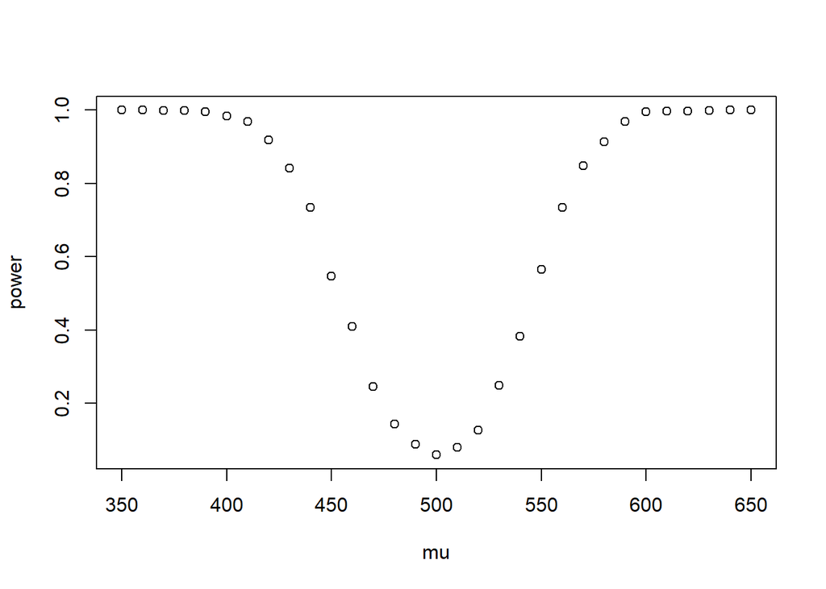

```r
n=20
m=1000
mu0=500
sigma=100
mu=c(seq(350, 650, 10)) #alternatives
M=length(mu)
power=numeric(M)
for (i in 1:M) {
  mu1=mu[i]
  pvalues <- replicate(m, expr = {
    #simulate under alternative mu1
    x=rnorm(n, mean = mu1, sd = sigma)
    ttest=t.test(x, alternative = "two.sided", mu = mu0)
    ttest$p.value } )
    power[i]=mean(pvalues <= .05)
}
plot(mu,power)
```

## Exercise 6

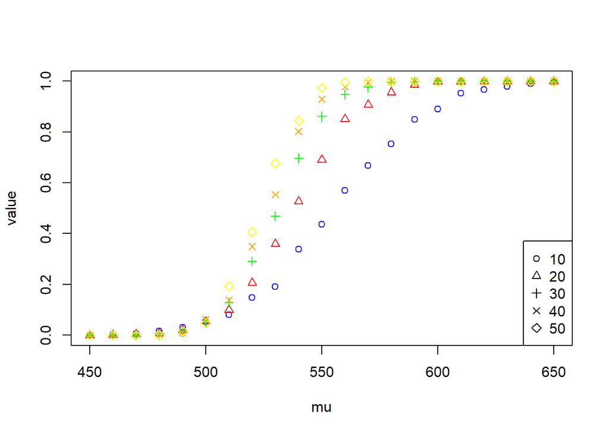

```r
n=c(seq(10,50,10)) #different sample sizes
m=1000
mu0=500
sigma=100
mu=c(seq(450, 650, 10)) #alternatives
M=length(mu)
power=matrix(0,M,length(n))
for (j in 1:length(n)){
for (i in 1:M) {
  mu1=mu[i]
  pvalues <- replicate(m, expr = {
    #simulate under alternative mu1
    x=rnorm(n[j], mean = mu1, sd = sigma)
    ttest=t.test(x, alternative = "greater", mu = mu0)
    ttest$p.value } )
  power[i,j]=mean(pvalues <= .05)
}}
# plot
plot(mu,power[,1],pch=1,col='blue',ylim=c(0,1),xlab='mu',ylab = 'value')
par(new=TRUE)
plot(mu,power[,2],pch=2, col='red',axes = FALSE,xlab = "", ylab = "",ylim=c(0,1))
par(new=TRUE)
plot(mu,power[,3],pch=3,col='green',axes = FALSE,xlab = "", ylab = "",ylim=c(0,1))
par(new=TRUE)
plot(mu,power[,4],pch=4,col='orange',axes = FALSE,xlab = "", ylab = "",ylim=c(0,1))
par(new=TRUE)
plot(mu,power[,5],pch=5,col='yellow',axes = FALSE,xlab = "", ylab = "",ylim=c(0,1))
legend("bottomright",legend = c("10","20","30","40","50"), pch = c(1,2,3,4,5))
```

From the plot, we can see that the bigger the sample size, the larger the power is.

## Exercise 7

```r
n=20
alpha=0.05
CL=replicate(1000, expr = {
  x=rchisq(n,2) #samples from chisquare(2)
  a=qt(alpha/2,n-1) * sd(x) / sqrt(n)
  c(mean(x)-a,mean(x)+a) }) #compute t-interval
theta=2 #theoretical mean of chisqure(2)
mean(CL[1,]>theta & CL[2,]<theta)
```

```
## [1] 0.925
```

```r
x <- rnorm(n, mean=0, sd=2)
UCL <- replicate(1000, expr = {
  x <- rnorm(n, mean = 0, sd = 2)
  (n-1) * var(x) / qchisq(alpha, df = n-1) })
result=rbind(UCL,numeric(1000),CL) #compare interval result with first two rows are the one in example and the last two rows are my result
result[,1:10] #for the large amount of intervals, here I only output 10 intervals for each example
```

```
##       [,1]    [,2]   [,3]   [,4]   [,5]  [,6]   [,7]   [,8]   [,9] [,10]
## UCL 4.4870 16.2075 11.625 13.778 11.034 7.712 5.0889 9.4143 7.1935 8.776
##     0.0000  0.0000  0.000  0.000  0.000 0.000 0.0000 0.0000 0.0000 0.000
##     2.9684  3.0079  3.110  3.067  2.888 2.974 3.3940 2.0391 2.5634 3.480
##     0.9815  0.9586  1.002  1.151  1.141 1.028 0.9416 0.3709 0.8696 1.179
```

We can clearly see that intervals from example 6.4 are a lot wider than t-intervals.

## Exercise 8

```r
count5test <- function(x, y) {
  X=x - mean(x)
  Y=y - mean(y)
  outx=sum(X > max(Y)) + sum(X < min(Y))
  outy=sum(Y > max(X)) + sum(Y < min(X))
  # return 1 (reject) or 0 (do not reject H0)
  return(as.integer(max(c(outx, outy)) > 5))
} # create count5test function
sigma1=1
sigma2=1.5
m=1000
s_size=c(20,200,1000) #here small sample=20; medium=200, large=1000
c5_power=numeric(3)
f_power=numeric(3)
f_I=numeric(m)
for (i in 1:3) {
  c5_power[i] = mean(replicate(m, expr = {
    x = rnorm(s_size[i], 0, sigma1)
    y = rnorm(s_size[i], 0, sigma2)
    count5test(x, y)
  }))
  for (j in 1:m) {
    x = rnorm(s_size[i], 0, sigma1)
    y = rnorm(s_size[i], 0, sigma2)
    f_I[j] = (var.test(x, y, alternative = "two.sided")$p.value < 0.055) #compute the number of rejecting H0
  }
  f_power[i]= mean(f_I)
}
rbind(c5_power,f_power)  #compare the powers of two tests
```

```
##          [,1]  [,2]  [,3]
## c5_power 0.32 0.951 0.995
## f_power  0.44 0.999 1.000
```